# Gun Violence

Author

Kristin Lloyd

```python
import geopandas as gpd

# Load U.S. state shapefile from Census Bureau
states_url = "https://www2.census.gov/geo/tiger/GENZ2018/shp/cb_2018_us_state_20m.zip"
states_map = gpd.read_file(states_url)

# Convert geometry to WKT format
states_map["geometry"] = states_map["geometry"].apply(lambda geom: geom.wkt)

# Select relevant columns
states_map = states_map[["NAME", "geometry"]]  # You can add more columns if needed

# Save as CSV
states_map.to_csv("data/us_states_geodata.csv", index=False)
```

## Problem & Objectives

Firearm mortality remains a pressing public health issue in the United States, with gun-related deaths accounting for a significant portion of homicides, suicides, and accidental fatalities. The complexity of this issue extends beyond crime statistics, encompassing social, economic, and policy-driven factors that influence gun violence trends. This project aims to analyze firearm mortality rates across U.S. states and examine the impact of gun control policies, domestic violence-related firearm deaths, and access to mental health resources. By identifying key contributing factors, this study seeks to provide insights into the effectiveness of existing regulations and potential strategies to mitigate firearm-related deaths. This project will contribute to the broader discourse on public safety and policy effectiveness in reducing gun violence.

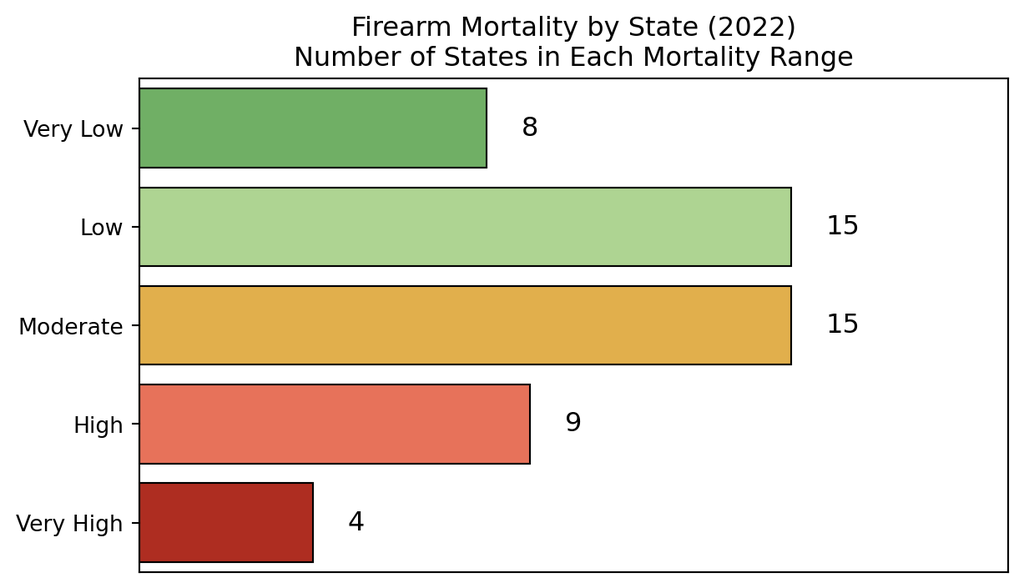

```python
import pandas as pd
import matplotlib.pyplot as plt
import seaborn as sns

# Load data
gun_deaths = pd.read_csv("data/merged_data.csv")

# Define bins and labels
bins = [0, 10, 15, 20, 25, float('inf')]
labels = ["Very Low", "Low", "Moderate", "High", "Very High"]  # Fixed the syntax error

# Assign bins, ensuring no overlap (excluding the right endpoint)
gun_deaths['mortality_bin'] = pd.cut(
    gun_deaths['firearm_mortality_by_state_2022'], bins=bins, labels=labels, right=False
)

# Count states in each bin
gun_death_distribution = gun_deaths['mortality_bin'].value_counts().sort_index().reset_index()
gun_death_distribution.columns = ['mortality_bin', 'State_Count']

# Define colors
colors = {
    "Very Low": "#68bb59",
    "Low": "#acdf87",
    "Moderate": "#fab733",
    "High": "#ff6242",
    "Very High": "#c61a09"
}

# Plot
title = "Firearm Mortality by State (2022)"
subtitle = "Number of States in Each Mortality Range"
plt.figure(figsize=(7, 4))  # Slightly increased width for better spacing
ax = sns.barplot(
    y='mortality_bin', x='State_Count', data=gun_death_distribution,
    order=labels, palette=colors, edgecolor='black', linewidth=.8  # Increased border width
)

# Add labels right outside the bars with better spacing
for index, value in enumerate(gun_death_distribution['State_Count']):
    ax.text(value + 0.8, index, str(value), va='center', ha='left', fontsize=12, color='black')

plt.title(f"{title}\n{subtitle}", fontsize=12, weight='normal')  # Unbolded title, smaller font
plt.xlabel("")
plt.ylabel("")
plt.xticks([])
plt.grid(axis='x', linestyle="--", alpha=0.7)
plt.xlim(0, gun_death_distribution['State_Count'].max() + 5)  # Added padding to the x-axis
plt.show()
```

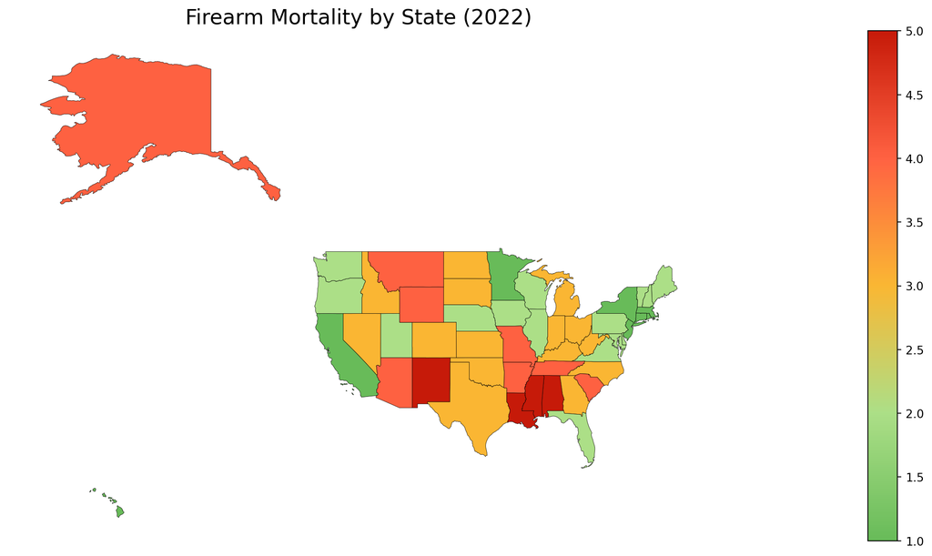

```python
import pandas as pd
import geopandas as gpd
import matplotlib.pyplot as plt
import seaborn as sns
from mpl_toolkits.axes_grid1 import make_axes_locatable
from matplotlib.colors import LinearSegmentedColormap
from shapely import wkt
from shapely.geometry import MultiPolygon
from shapely.wkt import dumps

# Load dataset
gun_deaths = pd.read_csv("data/merged_data.csv")

# Ensure state names are lowercase for merging
gun_deaths["State"] = gun_deaths["State"].str.lower()

# Define mortality bins and labels
mortality_bins = [0, 10, 15, 20, 25, float("inf")]
mortality_labels = [1, 2, 3, 4, 5]

# Assign states into mortality categories
gun_deaths["mortality_score"] = pd.cut(
    gun_deaths["firearm_mortality_by_state_2022"],
    bins=mortality_bins,
    labels=mortality_labels,
    right=False
).astype(float)

# Load U.S. state shapefile from Census Bureau
states_url = "https://www2.census.gov/geo/tiger/GENZ2018/shp/cb_2018_us_state_20m.zip"
states_map = gpd.read_file(states_url)

# Ensure lowercase for merging
states_map["region"] = states_map["NAME"].str.lower()

# Merge state map with gun deaths data
map_data = states_map.merge(gun_deaths, left_on="region", right_on="State", how="left")

# Remove Aleutian Islands from Alaska
alaska_index = map_data[map_data["region"] == "alaska"].index[0]
alaska_geom = map_data.loc[alaska_index, "geometry"]

# Ensure it's a MultiPolygon and filter out Aleutian Islands
if isinstance(alaska_geom, MultiPolygon):
    # Keep only the largest landmass (mainland Alaska)
    mainland_polygon = max(alaska_geom.geoms, key=lambda p: p.area)
    map_data.at[alaska_index, "geometry"] = mainland_polygon

# Define color map
colors = ["#68bb59", "#acdf87", "#fab733", "#ff6242", "#c61a09"]
cmap = LinearSegmentedColormap.from_list("custom_cmap", colors)

# Plot Gun Deaths by State
fig, ax = plt.subplots(figsize=(16, 10))
divider = make_axes_locatable(ax)
cax = divider.append_axes("right", size="3%", pad=0.2)

# Plot states
map_data.plot(column="mortality_score", cmap=cmap, linewidth=0.3, edgecolor="black", ax=ax, legend=True, cax=cax)

# Customize plot
ax.set_title("Firearm Mortality by State (2022)", fontsize=18)
ax.set_xticks([])
ax.set_yticks([])
ax.set_frame_on(False)

plt.show()
```

```python
'''
import pandas as pd
import geopandas as gpd
import matplotlib.pyplot as plt
import seaborn as sns
from mpl_toolkits.axes_grid1 import make_axes_locatable
from matplotlib.colors import LinearSegmentedColormap

# Load dataset
gun_deaths = pd.read_csv("data/merged_data.csv")

# Ensure state names are lowercase for merging
gun_deaths["State"] = gun_deaths["State"].str.lower()

# Define mortality bins and labels
mortality_bins = [0, 10, 15, 20, 25, float("inf")]
mortality_labels = [1, 2, 3, 4, 5]

# Assign states into mortality categories
gun_deaths["mortality_score"] = pd.cut(
    gun_deaths["firearm_mortality_by_state_2022"],
    bins=mortality_bins,
    labels=mortality_labels,
    right=False
).astype(float)

# Load U.S. state shapefile from Census Bureau
states_url = "https://www2.census.gov/geo/tiger/GENZ2018/shp/cb_2018_us_state_20m.zip"
states_map = gpd.read_file(states_url)

# Ensure lowercase for merging
states_map["region"] = states_map["NAME"].str.lower()

# Merge state map with gun deaths data
map_data = states_map.merge(gun_deaths, left_on="region", right_on="State", how="left")

# Ensure the geometry is converted back to WKT correctly
from shapely.wkt import dumps

# Reload dataset
geo_data = pd.read_csv("data/us_states_geodata.csv")

# Extract Alaska's geometry
alaska_geom = wkt.loads(geo_data.loc[geo_data["NAME"].str.lower() == "alaska", "geometry"].values[0])

# Ensure it's a MultiPolygon and filter out Aleutian Islands
if isinstance(alaska_geom, MultiPolygon):
    mainland_polygons = [p for p in alaska_geom.geoms if p.centroid.x > -160]
    new_alaska_geom = MultiPolygon(mainland_polygons)

    # Update the geometry in the dataset with the corrected WKT format
    geo_data.loc[geo_data["NAME"].str.lower() == "alaska", "geometry"] = dumps(new_alaska_geom)

# Save the cleaned dataset
cleaned_geo_data_path = "/data/cleaned_us_states_geodata.csv"
geo_data.to_csv(cleaned_geo_data_path, index=False)

# Provide the cleaned file path
print(cleaned_geo_data_path)

map_data = map_data[map_data["region"] != "alaska"]  # Remove original Alaska
new_geo_data = gpd.read_file("path/to/cleaned_us_states_geodata.csv")  # Load cleaned data
map_data = pd.concat([map_data, new_geo_data[new_geo_data["region"] == "alaska"]], ignore_index=True)  # Add fixed Alaska

# Define color map
colors = ["#68bb59", "#acdf87", "#fab733", "#ff6242", "#c61a09"]
cmap = LinearSegmentedColormap.from_list("custom_cmap", colors)

# Plot Gun Deaths by State
fig, ax = plt.subplots(figsize=(16, 10))
divider = make_axes_locatable(ax)
cax = divider.append_axes("right", size="3%", pad=0.2)

# Plot states
map_data.plot(column="mortality_score", cmap=cmap, linewidth=0.3, edgecolor="black", ax=ax, legend=True, cax=cax)

# Customize plot
ax.set_title("Firearm Mortality by State (2022)", fontsize=18)
ax.set_xticks([])
ax.set_yticks([])
ax.set_frame_on(False)

plt.show()
'''
```

[output not shown]

## Motivation and Case Studies

## Research Questions

**Data Science Question:**

**Subquestions:**